# CovidEDA

**COVID-19 Exploratory Data Analysis (EDA)**

**Introduction This notebook provides an in-depth analysis of COVID-19 cases, deaths, and vaccinations using two datasets:**

```python
import pandas as pd
import seaborn as sns
import matplotlib.pyplot as plt
import numpy as np
import plotly.express as px
import plotly.graph_objects as go
from datetime import datetime                    # For statistical data visualization
import warnings
warnings.filterwarnings('ignore')
```

load data set by csv

```python
death =pd.read_csv("COVID DEATHS.csv")
vaccine=pd.read_csv("COVID_VACCINATIONS.csv")
```

exploring data set for understanding

```python
death.shape
```

```
(302749, 26)
```

```python
vaccine.shape
```

```
(302749, 45)
```

```python
death.info()
```

```
<class 'pandas.core.frame.DataFrame'>
RangeIndex: 302749 entries, 0 to 302748
Data columns (total 26 columns):
 #   Column                              Non-Null Count   Dtype
---  ------                              --------------   -----
 0   iso_code                            302749 non-null  object
 1   continent                           288347 non-null  object
 2   location                            302749 non-null  object
 3   date                                302749 non-null  object
 4   population                          302749 non-null  int64
 5   total_cases                         266771 non-null  float64
 6   new_cases                           294064 non-null  float64
 7   new_cases_smoothed                  292800 non-null  float64
 8   total_deaths                        246214 non-null  float64
 9   new_deaths                          294139 non-null  float64
```

[output cut: 18 more lines]

```python
vaccine.info()
```

```
<class 'pandas.core.frame.DataFrame'>
RangeIndex: 302749 entries, 0 to 302748
Data columns (total 45 columns):
 #   Column                                      Non-Null Count   Dtype
---  ------                                      --------------   -----
 0   iso_code                                    302749 non-null  object
 1   continent                                   288347 non-null  object
 2   location                                    302749 non-null  object
 3   date                                        302749 non-null  object
 4   total_tests                                 79387 non-null   float64
 5   new_tests                                   75403 non-null   float64
 6   total_tests_per_thousand                    79387 non-null   float64
 7   new_tests_per_thousand                      75403 non-null   float64
 8   new_tests_smoothed                          103965 non-null  float64
 9   new_tests_smoothed_per_thousand             103965 non-null  float64
```

[output cut: 37 more lines]

```python
from IPython.display import display
pd.set_option('display.max_columns', None)
pd.set_option('display.max_rows', None)
```

```python
death.head()
```

|  | iso_code | continent | location | date | population | total_cases | new_cases | new_cases_smoothed | total_deaths | new_deaths | new_deaths_smoothed | total_cases_per_million | new_cases_per_million | new_cases_smoothed_per_million | total_deaths_per_million | new_deaths_per_million | new_deaths_smoothed_per_million | reproduction_rate | icu_patients | icu_patients_per_million | hosp_patients | hosp_patients_per_million | weekly_icu_admissions | weekly_icu_admissions_per_million | weekly_hosp_admissions | weekly_hosp_admissions_per_million |
| --- | --- | --- | --- | --- | --- | --- | --- | --- | --- | --- | --- | --- | --- | --- | --- | --- | --- | --- | --- | --- | --- | --- | --- | --- | --- | --- |
| 0 | AFG | Asia | Afghanistan | 1/3/2020 | 41128772 | NaN | 0.0 | NaN | NaN | 0.0 | NaN | NaN | 0.0 | NaN | NaN | 0.0 | NaN | NaN | NaN | NaN | NaN | NaN | NaN | NaN | NaN | NaN |
| 1 | AFG | Asia | Afghanistan | 1/4/2020 | 41128772 | NaN | 0.0 | NaN | NaN | 0.0 | NaN | NaN | 0.0 | NaN | NaN | 0.0 | NaN | NaN | NaN | NaN | NaN | NaN | NaN | NaN | NaN | NaN |
| 2 | AFG | Asia | Afghanistan | 1/5/2020 | 41128772 | NaN | 0.0 | NaN | NaN | 0.0 | NaN | NaN | 0.0 | NaN | NaN | 0.0 | NaN | NaN | NaN | NaN | NaN | NaN | NaN | NaN | NaN | NaN |
| 3 | AFG | Asia | Afghanistan | 1/6/2020 | 41128772 | NaN | 0.0 | NaN | NaN | 0.0 | NaN | NaN | 0.0 | NaN | NaN | 0.0 | NaN | NaN | NaN | NaN | NaN | NaN | NaN | NaN | NaN | NaN |
| 4 | AFG | Asia | Afghanistan | 1/7/2020 | 41128772 | NaN | 0.0 | NaN | NaN | 0.0 | NaN | NaN | 0.0 | NaN | NaN | 0.0 | NaN | NaN | NaN | NaN | NaN | NaN | NaN | NaN | NaN | NaN |

```python
vaccine.head()
```

|  | iso_code | continent | location | date | total_tests | new_tests | total_tests_per_thousand | new_tests_per_thousand | new_tests_smoothed | new_tests_smoothed_per_thousand | positive_rate | tests_per_case | tests_units | total_vaccinations | people_vaccinated | people_fully_vaccinated | total_boosters | new_vaccinations | new_vaccinations_smoothed | total_vaccinations_per_hundred | people_vaccinated_per_hundred | people_fully_vaccinated_per_hundred | total_boosters_per_hundred | new_vaccinations_smoothed_per_million | new_people_vaccinated_smoothed | new_people_vaccinated_smoothed_per_hundred | stringency_index | population_density | median_age | … |
| --- | --- | --- | --- | --- | --- | --- | --- | --- | --- | --- | --- | --- | --- | --- | --- | --- | --- | --- | --- | --- | --- | --- | --- | --- | --- | --- | --- | --- | --- | --- |
| 0 | AFG | Asia | Afghanistan | 1/3/2020 | NaN | NaN | NaN | NaN | NaN | NaN | NaN | NaN | NaN | NaN | NaN | NaN | NaN | NaN | NaN | NaN | NaN | NaN | NaN | NaN | NaN | NaN | NaN | 54.42 | 18.6 | … |
| 1 | AFG | Asia | Afghanistan | 1/4/2020 | NaN | NaN | NaN | NaN | NaN | NaN | NaN | NaN | NaN | NaN | NaN | NaN | NaN | NaN | NaN | NaN | NaN | NaN | NaN | NaN | NaN | NaN | NaN | 54.42 | 18.6 | … |
| 2 | AFG | Asia | Afghanistan | 1/5/2020 | NaN | NaN | NaN | NaN | NaN | NaN | NaN | NaN | NaN | NaN | NaN | NaN | NaN | NaN | NaN | NaN | NaN | NaN | NaN | NaN | NaN | NaN | NaN | 54.42 | 18.6 | … |
| 3 | AFG | Asia | Afghanistan | 1/6/2020 | NaN | NaN | NaN | NaN | NaN | NaN | NaN | NaN | NaN | NaN | NaN | NaN | NaN | NaN | NaN | NaN | NaN | NaN | NaN | NaN | NaN | NaN | NaN | 54.42 | 18.6 | … |
| 4 | AFG | Asia | Afghanistan | 1/7/2020 | NaN | NaN | NaN | NaN | NaN | NaN | NaN | NaN | NaN | NaN | NaN | NaN | NaN | NaN | NaN | NaN | NaN | NaN | NaN | NaN | NaN | NaN | NaN | 54.42 | 18.6 | … |

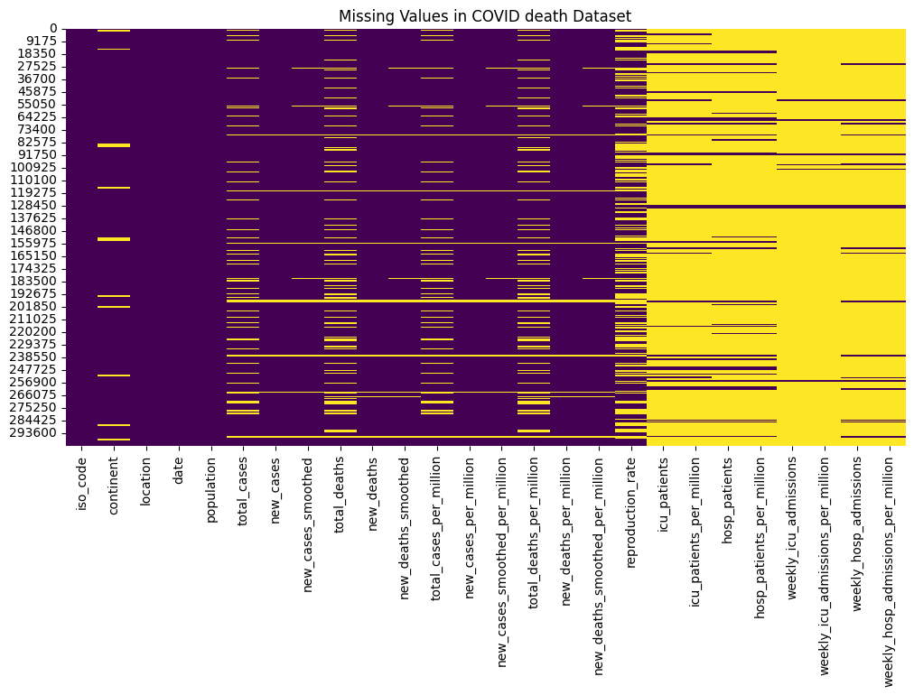

```python
plt.figure(figsize=(12,6))
sns.heatmap(death.isnull(),cbar=False,cmap="viridis")
plt.title("Missing Values in COVID death Dataset")
plt.show()
```

cbar=False cbar stands for color bar.

False means do not show the color bar (legend) on the side.

✅ Use When: You want a cleaner look and the color scale (legend) isn't necessary

🔸 cmap='viridis' cmap stands for colormap.

'viridis' is a color gradient that transitions from dark purple → yellow.

✅ Use When: You want to apply a custom color style to your heatmap.

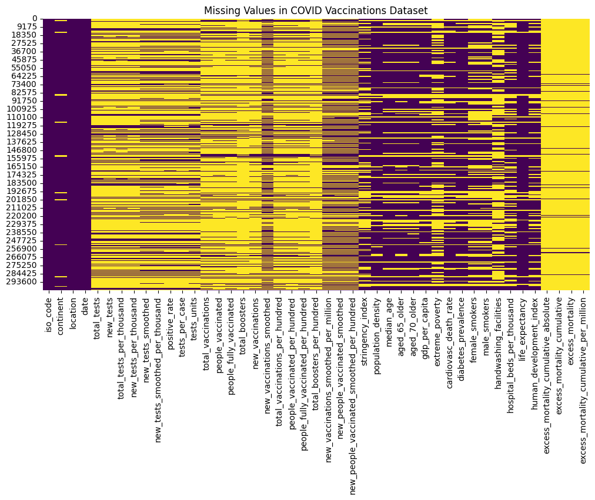

```python
plt.figure(figsize=(12,6))
sns.heatmap(vaccine.isnull(),cbar=False,cmap="viridis")
plt.title("Missing Values in COVID Vaccinations Dataset")
plt.show()
```

```python
missing_deaths=death.isnull().sum()/len(death)*100
```

```python
missing_vaccine=vaccine.isnull().sum()/len(vaccine)*100
```

```python
missing_deaths[missing_deaths>10].sort_values(ascending=False)
```

```
weekly_icu_admissions                 96.981328
weekly_icu_admissions_per_million     96.981328
weekly_hosp_admissions                92.942008
weekly_hosp_admissions_per_million    92.942008
icu_patients                          88.483529
icu_patients_per_million              88.483529
hosp_patients                         88.359334
hosp_patients_per_million             88.359334
reproduction_rate                     38.953721
total_deaths                          18.673885
total_deaths_per_million              18.673885
total_cases                           11.883772
total_cases_per_million               11.883772
dtype: float64
```

```python
missing_vaccine[missing_vaccine>20].sort_values(ascending=False)
```

```
excess_mortality_cumulative_per_million       96.599493
excess_mortality                              96.599493
excess_mortality_cumulative                   96.599493
excess_mortality_cumulative_absolute          96.599493
total_boosters_per_hundred                    85.967584
total_boosters                                85.967584
new_vaccinations                              79.950388
people_fully_vaccinated_per_hundred           77.428827
people_fully_vaccinated                       77.428827
people_vaccinated                             76.682665
people_vaccinated_per_hundred                 76.682665
total_vaccinations_per_hundred                75.640877
total_vaccinations                            75.640877
new_tests_per_thousand                        75.093890
new_tests                                     75.093890
total_tests                                   73.777948
total_tests_per_thousand                      73.777948
tests_per_case                                68.836231
positive_rate                                 68.314677
new_tests_smoothed                            65.659672
new_tests_smoothed_per_thousand               65.659672
tests_units                                   64.727216
handwashing_facilities                        62.065936
extreme_poverty                               50.191413
new_vaccinations_smoothed                     45.834668
new_vaccinations_smoothed_per_million         45.834668
new_people_vaccinated_smoothed_per_hundred    45.810226
new_people_vaccinated_smoothed                45.810226
male_smokers                                  42.671322
female_smokers                                41.880898
stringency_index                              36.186742
hospital_beds_per_thousand                    31.611335
human_development_index                       24.901816
aged_65_older                                 23.845826
gdp_per_capita                                22.663328
cardiovasc_death_rate                         22.526251
aged_70_older                                 21.874556
median_age                                    21.082811
dtype: float64
```

```python
combined=pd.merge(death,vaccine,how='outer')
```

```python
combined.isnull().sum()
```

```
iso_code                                           0
continent                                      14402
location                                           0
date                                               0
population                                         0
total_cases                                    35978
new_cases                                       8685
new_cases_smoothed                              9949
total_deaths                                   56535
new_deaths                                      8610
new_deaths_smoothed                             9840
total_cases_per_million                        35978
new_cases_per_million                           8685
new_cases_smoothed_per_million                  9949
total_deaths_per_million                       56535
new_deaths_per_million                          8610
new_deaths_smoothed_per_million                 9840
reproduction_rate                             117932
icu_patients                                  267883
icu_patients_per_million                      267883
hosp_patients                                 267507
hosp_patients_per_million                     267507
weekly_icu_admissions                         293610
weekly_icu_admissions_per_million             293610
weekly_hosp_admissions                        281381
weekly_hosp_admissions_per_million            281381
total_tests                                   223362
new_tests                                     227346
total_tests_per_thousand                      223362
new_tests_per_thousand                        227346
new_tests_smoothed                            198784
new_tests_smoothed_per_thousand               198784
positive_rate                                 206822
tests_per_case                                208401
tests_units                                   195961
total_vaccinations                            229002
people_vaccinated                             232156
people_fully_vaccinated                       234415
total_boosters                                260266
new_vaccinations                              242049
```

[output cut: 13 more lines]

```
gdp_per_capita                                 68613
extreme_poverty                               151954
cardiovasc_death_rate                          68198
diabetes_prevalence                            56244
female_smokers                                126794
male_smokers                                  129187
handwashing_facilities                        187904
hospital_beds_per_thousand                     95703
life_expectancy                                24360
human_development_index                        75390
excess_mortality_cumulative_absolute          292454
excess_mortality_cumulative                   292454
excess_mortality                              292454
excess_mortality_cumulative_per_million       292454
dtype: int64
```

how='outer': Performs an outer join, meaning:

Keeps all rows from both DataFrames.

Fills missing values with NaN where no match is found.

```python
combined.shape
```

```
(302749, 67)
```

**data cleaning**

```python
null_prec=combined.isnull().sum()/len(combined)
```

```python
null_prec.sort_values(ascending=False)
```

```
weekly_icu_admissions_per_million             0.969813
weekly_icu_admissions                         0.969813
excess_mortality_cumulative_per_million       0.965995
excess_mortality                              0.965995
excess_mortality_cumulative                   0.965995
excess_mortality_cumulative_absolute          0.965995
weekly_hosp_admissions_per_million            0.929420
weekly_hosp_admissions                        0.929420
icu_patients_per_million                      0.884835
icu_patients                                  0.884835
hosp_patients_per_million                     0.883593
hosp_patients                                 0.883593
total_boosters                                0.859676
total_boosters_per_hundred                    0.859676
new_vaccinations                              0.799504
people_fully_vaccinated                       0.774288
people_fully_vaccinated_per_hundred           0.774288
people_vaccinated                             0.766827
people_vaccinated_per_hundred                 0.766827
total_vaccinations_per_hundred                0.756409
total_vaccinations                            0.756409
new_tests_per_thousand                        0.750939
new_tests                                     0.750939
total_tests                                   0.737779
total_tests_per_thousand                      0.737779
tests_per_case                                0.688362
positive_rate                                 0.683147
new_tests_smoothed                            0.656597
new_tests_smoothed_per_thousand               0.656597
tests_units                                   0.647272
handwashing_facilities                        0.620659
extreme_poverty                               0.501914
new_vaccinations_smoothed                     0.458347
new_vaccinations_smoothed_per_million         0.458347
new_people_vaccinated_smoothed                0.458102
new_people_vaccinated_smoothed_per_hundred    0.458102
male_smokers                                  0.426713
female_smokers                                0.418809
reproduction_rate                             0.389537
stringency_index                              0.361867
```

[output cut: 13 more lines]

```
life_expectancy                               0.080463
continent                                     0.047571
new_cases_smoothed                            0.032862
new_cases_smoothed_per_million                0.032862
new_deaths_smoothed                           0.032502
new_deaths_smoothed_per_million               0.032502
new_cases_per_million                         0.028687
new_cases                                     0.028687
new_deaths                                    0.028439
new_deaths_per_million                        0.028439
population                                    0.000000
date                                          0.000000
location                                      0.000000
iso_code                                      0.000000
dtype: float64
```

Dropping all columns who have >45% of missing data

```python
def remove_null_column(data):
    perc=0.45
    df=data.copy()
    remove_cols=(df.isnull().sum()/len(df))
    remove_cols=list(remove_cols[remove_cols.values>=perc].index)
    df.drop(labels=remove_cols,axis=1,inplace=True)
    return df
```

```python
combined1 = remove_null_column(combined)
```

null% afterremove columns in the data set

```python
null_prec1=combined1.isnull().sum()/len(combined1)
```

```python
null_prec1
```

```
iso_code                           0.000000
continent                          0.047571
location                           0.000000
date                               0.000000
population                         0.000000
total_cases                        0.118838
new_cases                          0.028687
new_cases_smoothed                 0.032862
total_deaths                       0.186739
new_deaths                         0.028439
new_deaths_smoothed                0.032502
total_cases_per_million            0.118838
new_cases_per_million              0.028687
new_cases_smoothed_per_million     0.032862
total_deaths_per_million           0.186739
new_deaths_per_million             0.028439
new_deaths_smoothed_per_million    0.032502
reproduction_rate                  0.389537
stringency_index                   0.361867
population_density                 0.151548
median_age                         0.210828
aged_65_older                      0.238458
aged_70_older                      0.218746
gdp_per_capita                     0.226633
cardiovasc_death_rate              0.225263
diabetes_prevalence                0.185778
female_smokers                     0.418809
male_smokers                       0.426713
hospital_beds_per_thousand         0.316113
life_expectancy                    0.080463
human_development_index            0.249018
dtype: float64
```

```python
combined1.shape
```

```
(302749, 31)
```

```python
combined1.dropna(subset=['continent'], inplace=True)
```

```python
combined1.shape
```

```
(288347, 31)
```

data transformation

```python
combined1.head()
```

|  | iso_code | continent | location | date | population | total_cases | new_cases | new_cases_smoothed | total_deaths | new_deaths | new_deaths_smoothed | total_cases_per_million | new_cases_per_million | new_cases_smoothed_per_million | total_deaths_per_million | new_deaths_per_million | new_deaths_smoothed_per_million | reproduction_rate | stringency_index | population_density | median_age | aged_65_older | aged_70_older | gdp_per_capita | cardiovasc_death_rate | diabetes_prevalence | female_smokers | male_smokers | hospital_beds_per_thousand | … |
| --- | --- | --- | --- | --- | --- | --- | --- | --- | --- | --- | --- | --- | --- | --- | --- | --- | --- | --- | --- | --- | --- | --- | --- | --- | --- | --- | --- | --- | --- | --- |
| 0 | ABW | North America | Aruba | 1/1/2021 | 106459 | 5442.0 | 69.0 | 30.571 | 49.0 | 0.0 | 0.286 | 51118.271 | 648.137 | 287.166 | 460.271 | 0.0 | 2.684 | NaN | 35.19 | 584.8 | 41.2 | 13.09 | 7.45 | 35973.78 | NaN | 11.62 | NaN | NaN | NaN | … |
| 1 | ABW | North America | Aruba | 1/1/2022 | 106459 | 19719.0 | 698.0 | 364.857 | 181.0 | 0.0 | 0.000 | 185226.237 | 6556.515 | 3427.208 | 1700.185 | 0.0 | 0.000 | NaN | 34.26 | 584.8 | 41.2 | 13.09 | 7.45 | 35973.78 | NaN | 11.62 | NaN | NaN | NaN | … |
| 2 | ABW | North America | Aruba | 1/1/2023 | 106459 | 43860.0 | 0.0 | 15.429 | 280.0 | 0.0 | 0.000 | 411989.592 | 0.000 | 144.925 | 2630.121 | 0.0 | 0.000 | NaN | NaN | 584.8 | 41.2 | 13.09 | 7.45 | 35973.78 | NaN | 11.62 | NaN | NaN | NaN | … |
| 3 | ABW | North America | Aruba | 1/10/2020 | 106459 | NaN | 0.0 | 0.000 | NaN | 0.0 | 0.000 | NaN | 0.000 | 0.000 | NaN | 0.0 | 0.000 | NaN | NaN | 584.8 | 41.2 | 13.09 | 7.45 | 35973.78 | NaN | 11.62 | NaN | NaN | NaN | … |
| 4 | ABW | North America | Aruba | 1/10/2021 | 106459 | 5883.0 | 0.0 | 63.000 | 50.0 | 0.0 | 0.143 | 55260.711 | 0.000 | 591.777 | 469.664 | 0.0 | 1.342 | NaN | 40.74 | 584.8 | 41.2 | 13.09 | 7.45 | 35973.78 | NaN | 11.62 | NaN | NaN | NaN | … |

```python
combined1.columns
```

```
Index(['iso_code', 'continent', 'location', 'date', 'population',
       'total_cases', 'new_cases', 'new_cases_smoothed', 'total_deaths',
       'new_deaths', 'new_deaths_smoothed', 'total_cases_per_million',
       'new_cases_per_million', 'new_cases_smoothed_per_million',
       'total_deaths_per_million', 'new_deaths_per_million',
       'new_deaths_smoothed_per_million', 'reproduction_rate',
       'stringency_index', 'population_density', 'median_age', 'aged_65_older',
       'aged_70_older', 'gdp_per_capita', 'cardiovasc_death_rate',
       'diabetes_prevalence', 'female_smokers', 'male_smokers',
       'hospital_beds_per_thousand', 'life_expectancy',
       'human_development_index'],
      dtype='object')
```

COlumns to keep

```python
new_columns=[ 'continent', 'location', 'date', 'population',
              'total_cases', 'new_cases', 'total_deaths', 'new_deaths',
              'reproduction_rate', 'stringency_index', 'population_density',
              'median_age', 'gdp_per_capita', 'diabetes_prevalence',
              'hospital_beds_per_thousand', 'life_expectancy']
combined1=combined1[new_columns]
```

```python
combined1.columns
```

```
Index(['continent', 'location', 'date', 'population', 'total_cases',
       'new_cases', 'total_deaths', 'new_deaths', 'reproduction_rate',
       'stringency_index', 'population_density', 'median_age',
       'gdp_per_capita', 'diabetes_prevalence', 'hospital_beds_per_thousand',
       'life_expectancy'],
      dtype='object')
```

```python
null_prec1=combined1.isnull().sum()/len(combined1)*100
```

```python
null_prec1.sort_values()
```

```
continent                      0.000000
location                       0.000000
date                           0.000000
population                     0.000000
new_deaths                     2.968645
new_cases                      2.994656
life_expectancy                3.869990
population_density            11.333567
total_cases                   12.385771
diabetes_prevalence           14.927501
median_age                    17.557665
gdp_per_capita                19.217124
total_deaths                  19.417230
hospital_beds_per_thousand    28.612054
stringency_index              32.999476
reproduction_rate             36.277818
dtype: float64
```

```python
null_prec=null_prec1[null_prec1>0].sort_values(ascending=False)
```

```python
null_prec
```

```
reproduction_rate             36.277818
stringency_index              32.999476
hospital_beds_per_thousand    28.612054
total_deaths                  19.417230
gdp_per_capita                19.217124
median_age                    17.557665
diabetes_prevalence           14.927501
total_cases                   12.385771
population_density            11.333567
life_expectancy                3.869990
new_cases                      2.994656
new_deaths                     2.968645
dtype: float64
```

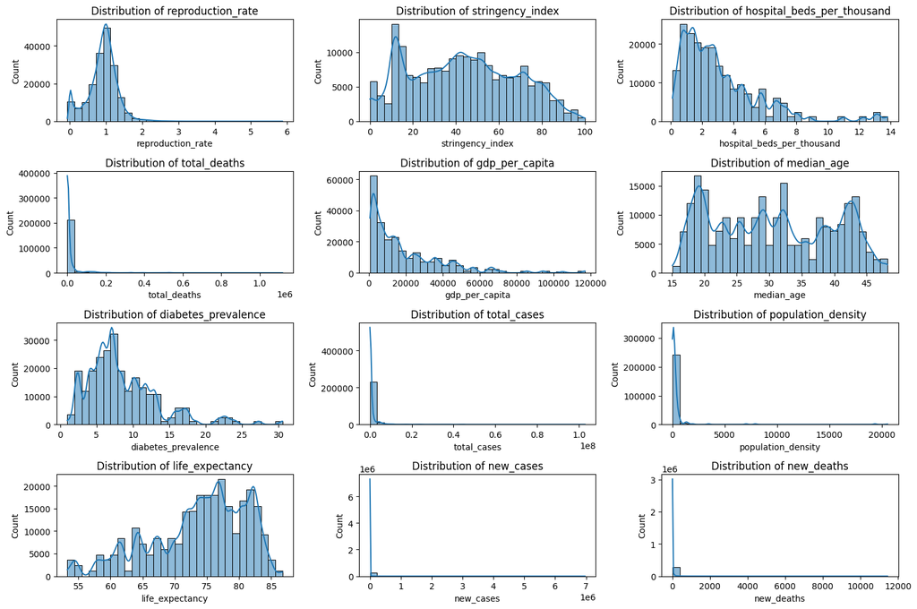

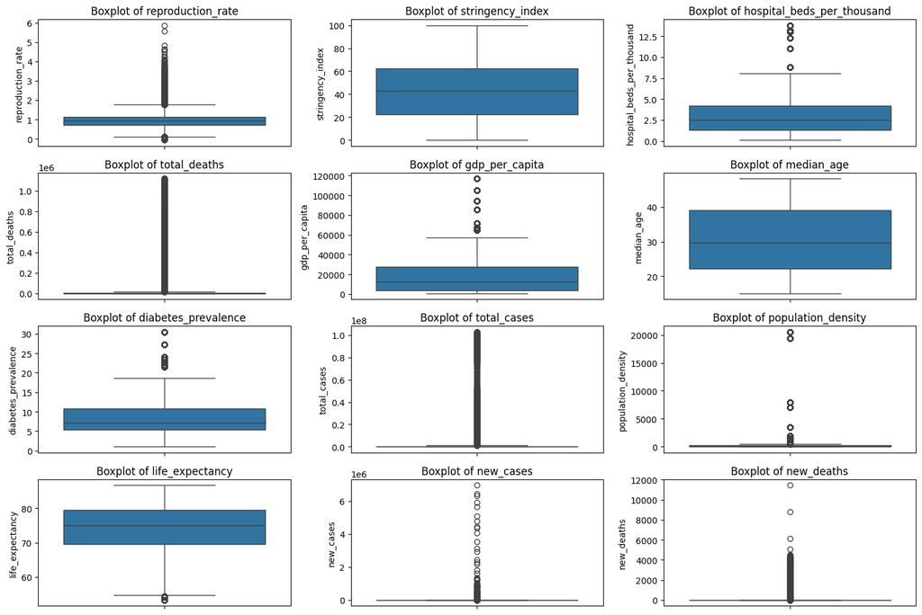

```python
import matplotlib.pyplot as plt
import seaborn as sns

# List of columns with missing values
missing_cols = ['reproduction_rate', 'stringency_index', 'hospital_beds_per_thousand',
                'total_deaths', 'gdp_per_capita', 'median_age', 'diabetes_prevalence',
                'total_cases', 'population_density', 'life_expectancy', 'new_cases', 'new_deaths']

# Plot histograms
plt.figure(figsize=(15, 10))
for i, col in enumerate(missing_cols, 1):
    plt.subplot(4, 3, i)
    sns.histplot(combined1[col], bins=30, kde=True)
    plt.title(f'Distribution of {col}')
plt.tight_layout()
plt.show()

# Plot boxplots for skewed data detection
plt.figure(figsize=(15, 10))
for i, col in enumerate(missing_cols, 1):
    plt.subplot(4, 3, i)
    sns.boxplot(y=combined1[col])
    plt.title(f'Boxplot of {col}')
plt.tight_layout()
plt.show()
```

Handling missing values based on distribution

```python
# Handling missing values based on distribution
# mean imputation in normally distribution
mean_impute_cols = ['reproduction_rate', 'stringency_index', 'median_age', 'life_expectancy']
combined1[mean_impute_cols] = combined1[mean_impute_cols].fillna(combined1[mean_impute_cols].mean())
#skewed in median imputation
median_impute_cols = ['hospital_beds_per_thousand', 'gdp_per_capita', 'diabetes_prevalence', 'population_density']
combined1[median_impute_cols] = combined1[median_impute_cols].fillna(combined1[median_impute_cols].median())
#forward fill in time series feature
time_series_fill_cols = ['total_cases', 'total_deaths', 'new_cases', 'new_deaths']
combined1[time_series_fill_cols] = combined1[time_series_fill_cols].fillna(method='ffill').fillna(method='bfill')


print("Remaining Missing Values After Imputation:")
print(combined1.isnull().sum()[combined1.isnull().sum() > 0])
```

```
Remaining Missing Values After Imputation:
Series([], dtype: int64)
```

```python
combined1.isnull().sum()
```

```
continent                     0
location                      0
date                          0
population                    0
total_cases                   0
new_cases                     0
total_deaths                  0
new_deaths                    0
reproduction_rate             0
stringency_index              0
population_density            0
median_age                    0
gdp_per_capita                0
diabetes_prevalence           0
hospital_beds_per_thousand    0
life_expectancy               0
dtype: int64
```

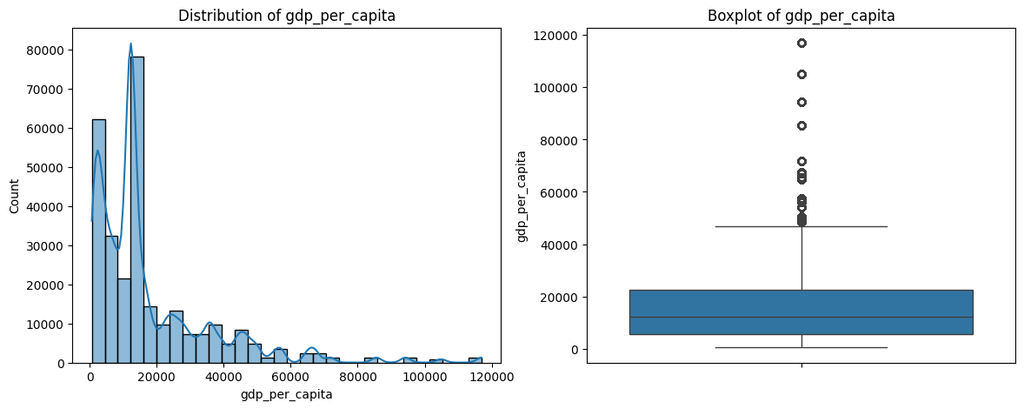

```python
def univariate_analysis(df, column):
    """
    Generate histogram & boxplot for a given column.
    """
    plt.figure(figsize=(14, 5))

    # Histogram & KDE plot
    plt.subplot(1, 2, 1)
    sns.histplot(df[column], bins=30, kde=True)
    plt.title(f"Distribution of {column}")

    # Boxplot
    plt.subplot(1, 2, 2)
    sns.boxplot(y=df[column])
    plt.title(f"Boxplot of {column}")

    plt.show()

# Example: Run this function for each column separately
column_name = 'gdp_per_capita'  # Change column name for each analysis
univariate_analysis(combined1, column_name)
```

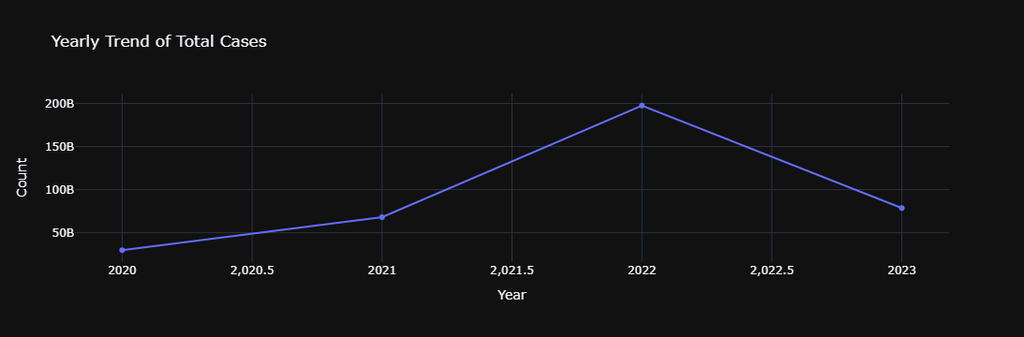

```python
import pandas as pd
import plotly.express as px

def plot_yearly_univariate(df, column, title):
    """
    Function to generate a line plot for a single column over the years.

    Parameters:
    df (DataFrame): The dataset containing COVID-19 data
    column (str): Column to plot
    title (str): Title of the plot
    """
    # Convert date to datetime format and extract year
    df['date'] = pd.to_datetime(df['date'])
    df['year'] = df['date'].dt.year

    # Group data by year and sum the selected column
    yearly_data = df.groupby('year')[column].sum().reset_index()

    # Create a line plot for a single column
    fig = px.line(yearly_data, x='year', y=column,
                  markers=True, title=title, template="plotly_dark")

    fig.update_layout(yaxis_title="Count", xaxis_title="Year")
    fig.show()

# Call function separately for each metric
plot_yearly_univariate(combined1, 'total_cases', "Yearly Trend of Total Cases")
```

Observation: no of cases increased from 2020-2022 , and decreased after 2022

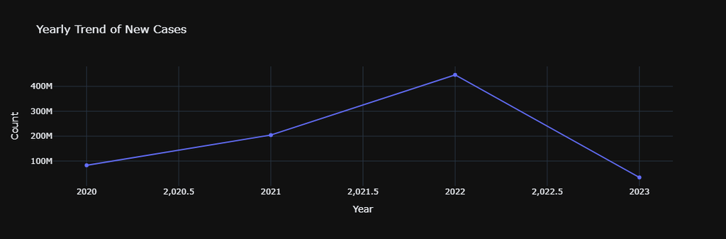

```python
plot_yearly_univariate(combined1, 'new_cases', "Yearly Trend of New Cases")
```

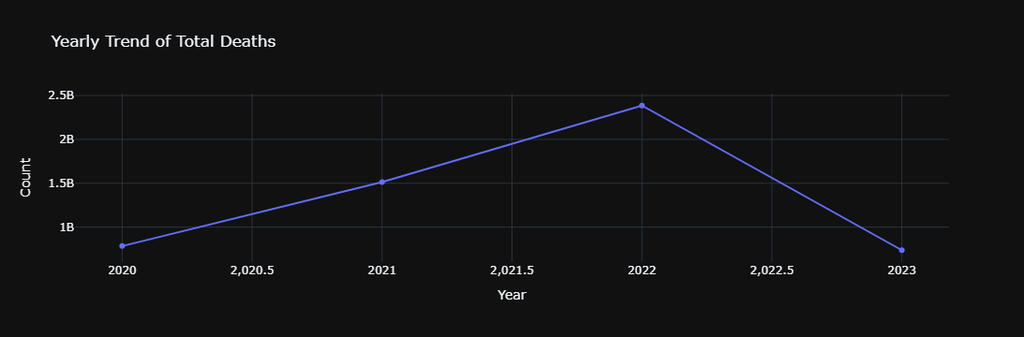

```python
plot_yearly_univariate(combined1, 'total_deaths', "Yearly Trend of Total Deaths")
```

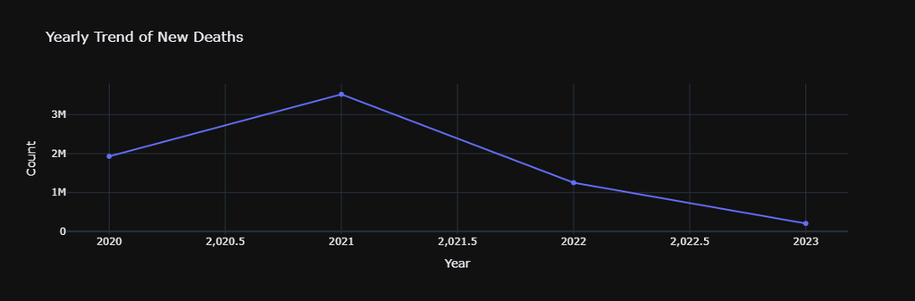

```python
plot_yearly_univariate(combined1, 'new_deaths', "Yearly Trend of New Deaths")
```

Visualizing the Trend of Cases throughout months of different Years

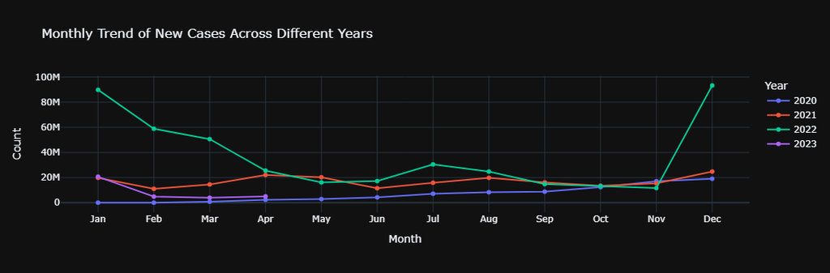

```python
import pandas as pd
import plotly.express as px

def plot_monthly_trend(df, column, title):
    """
    Function to generate a line plot for a given column, showing monthly trends across different years.

    Parameters:
    df (DataFrame): The dataset containing COVID-19 data
    column (str): Column to analyze (e.g., 'new_cases', 'new_deaths')
    title (str): Title of the plot
    """
    # Convert date to datetime format
    df['date'] = pd.to_datetime(df['date'])

    # Extract year and month
    df['year'] = df['date'].dt.year
    df['month'] = df['date'].dt.month

    # Group data by year and month, summing the column
    monthly_data = df.groupby(['year', 'month'])[column].sum().reset_index()

    # Convert month number to month name for better readability
    monthly_data['month'] = monthly_data['month'].apply(lambda x: pd.to_datetime(str(x), format='%m').strftime('%b'))

    # Create a line plot using Plotly
    fig = px.line(monthly_data, x='month', y=column, color='year',
                  markers=True, title=title, template="plotly_dark",
                  labels={'month': 'Month', column: 'Count'})

    fig.update_layout(yaxis_title="Count", xaxis_title="Month", legend_title="Year")
    fig.show()

# Call function for different metrics
plot_monthly_trend(combined1, 'new_cases', "Monthly Trend of New Cases Across Different Years")
```

Observations: 2020: linear trend towards increasing number of cases 2021: 2022: large number of cases, sudden increasein cases in nov-dec ( potentially indicates some new variant of covid virus) 2023: number of cases are fairly low

### Visualization of Top 10 Countries by COVID-19 Cases Over Years

```python
combined1.columns
```

```
Index(['continent', 'location', 'date', 'population', 'total_cases',
       'new_cases', 'total_deaths', 'new_deaths', 'reproduction_rate',
       'stringency_index', 'population_density', 'median_age',
       'gdp_per_capita', 'diabetes_prevalence', 'hospital_beds_per_thousand',
       'life_expectancy', 'year', 'month'],
      dtype='object')
```

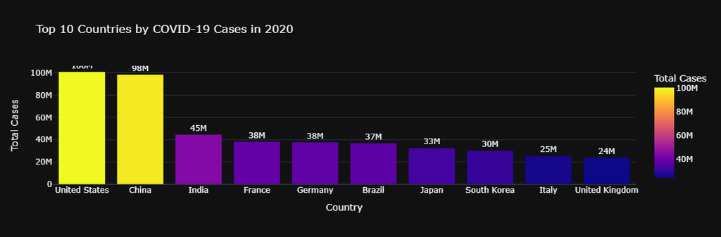

```python
import pandas as pd
import plotly.express as px

def plot_top_countries_cases(df, year):
    """
    Function to visualize the Top 10 countries by total COVID-19 cases for a given year.

    Parameters:
    df (DataFrame): The dataset containing COVID-19 data
    year (int): The year for which to plot the top 10 countries
    """
    # Filter data for the selected year
    df_year = df[df['year'] == year]

    # Group by country (location) and sum total cases
    country_cases = df_year.groupby('location')['total_cases'].max().reset_index()

    # Select the top 10 countries with the highest cases
    top_countries = country_cases.nlargest(10, 'total_cases')

    # Create a bar chart using Plotly
    fig = px.bar(top_countries, x='location', y='total_cases',
                 text='total_cases', title=f"Top 10 Countries by COVID-19 Cases in {year}",
                 labels={'total_cases': 'Total Cases', 'location': 'Country'},
                 template="plotly_dark", color='total_cases')

    fig.update_traces(texttemplate='%{text:.2s}', textposition='outside')
    fig.update_layout(xaxis_title="Country", yaxis_title="Total Cases")
    fig.show()

# Example: Plot for different years
plot_top_countries_cases(combined1, 2020)
```

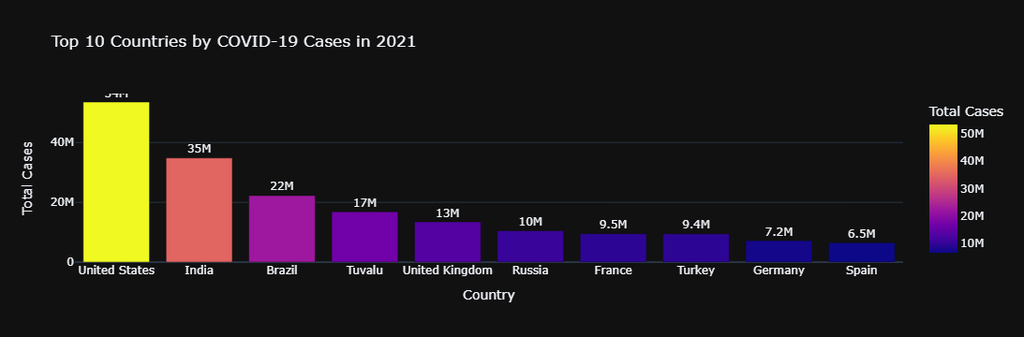

```python
plot_top_countries_cases(combined1, 2021)
```

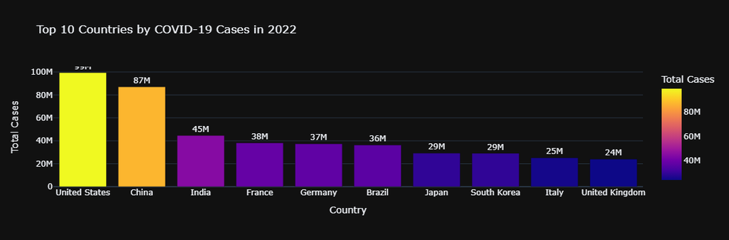

```python
plot_top_countries_cases(combined1, 2022)
```

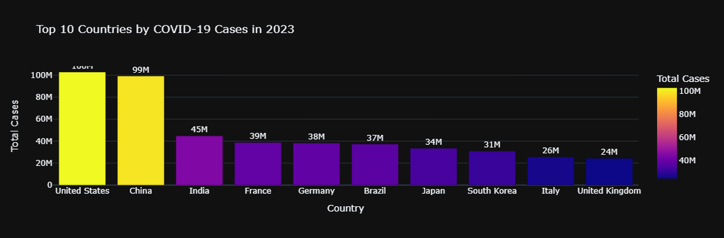

```python
plot_top_countries_cases(combined1, 2023)
```

Realtionship between GDP and cases

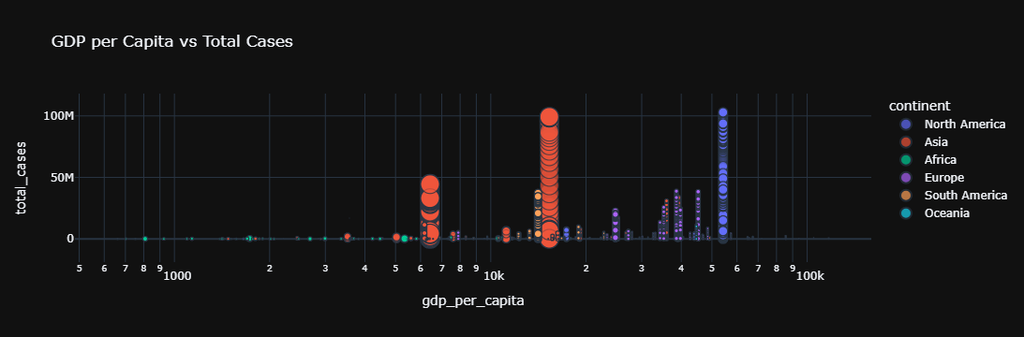

```python
def plot_gdp_vs_cases(df):
    fig = px.scatter(df, x='gdp_per_capita', y='total_cases', color='continent',
                     size='population', title="GDP per Capita vs Total Cases",
                     hover_name='location', log_x=True, template="plotly_dark")
    fig.show()

plot_gdp_vs_cases(combined1)
```

**Observation: higher GDP (right side) tend to more cases** **low gdp countries have fewer reported cases**

Impact of Population Density on COVID-19 Spread

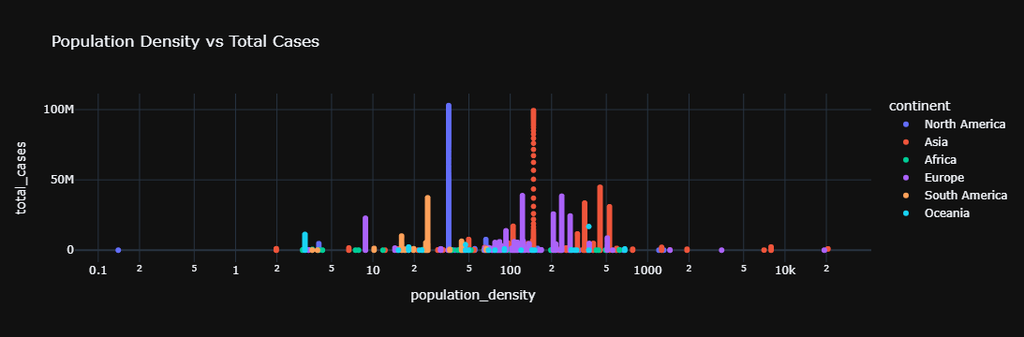

```python
def plot_population_density_vs_cases(df):
    fig = px.scatter(df, x='population_density', y='total_cases', color='continent',
                     title="Population Density vs Total Cases",
                     hover_name='location', log_x=True, template="plotly_dark")
    fig.show()

plot_population_density_vs_cases(combined1)

# Hypothesis: Densely populated areas may have higher COVID-19 cases.
```

### Correlation Between Stringency Index & Cases Over Time

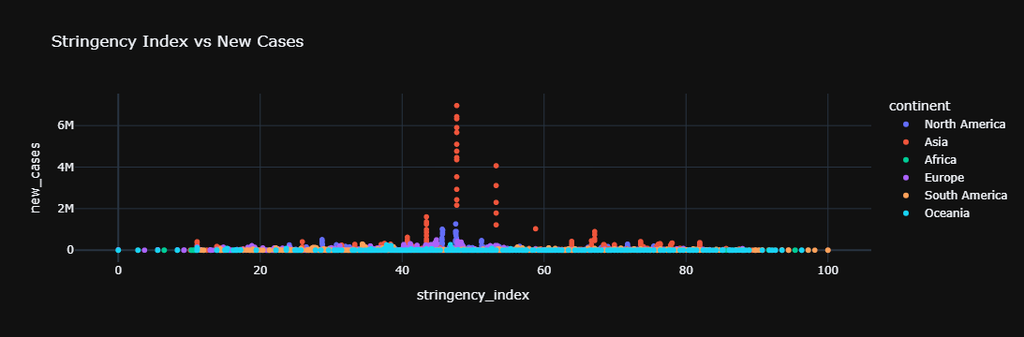

```python
def plot_stringency_vs_cases(df):
    fig = px.scatter(df, x='stringency_index', y='new_cases', color='continent',
                     title="Stringency Index vs New Cases",
                     hover_name='location', template="plotly_dark")
    fig.show()

plot_stringency_vs_cases(combined1)
```

### Treemap – Total Cases by Continent & Country

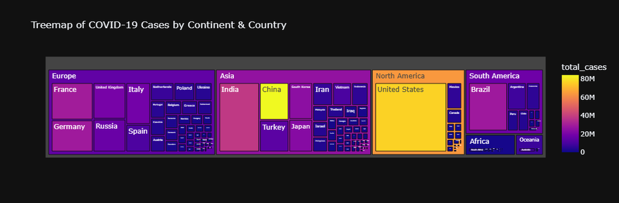

```python
def plot_treemap_cases(df):
    fig = px.treemap(df, path=['continent', 'location'], values='total_cases',
                     title="Treemap of COVID-19 Cases by Continent & Country",
                     color='total_cases', template="plotly_dark")
    fig.show()

plot_treemap_cases(combined1)
```

### Bar Chart – Top 10 Countries by Total Deaths

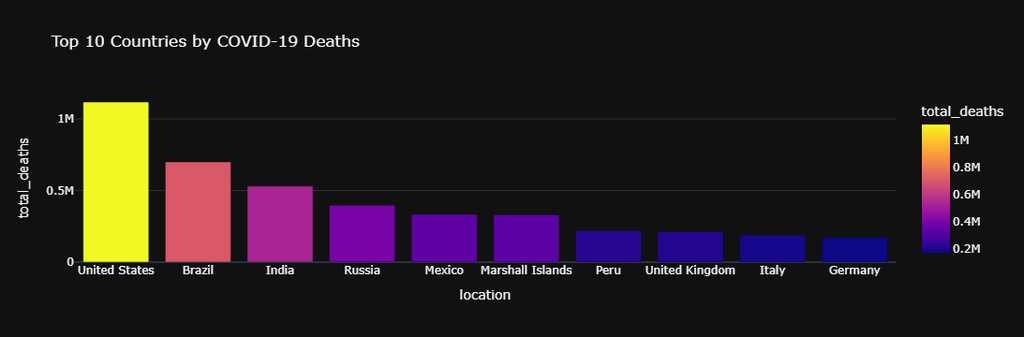

```python
def plot_top_10_countries_deaths(df):
    top_countries = df.groupby('location')['total_deaths'].max().reset_index()
    top_countries = top_countries.nlargest(10, 'total_deaths')

    fig = px.bar(top_countries, x='location', y='total_deaths', color='total_deaths',
                 title="Top 10 Countries by COVID-19 Deaths", template="plotly_dark")
    fig.show()

plot_top_10_countries_deaths(combined1)
```

### Hospital Beds per Thousand vs Death Rate

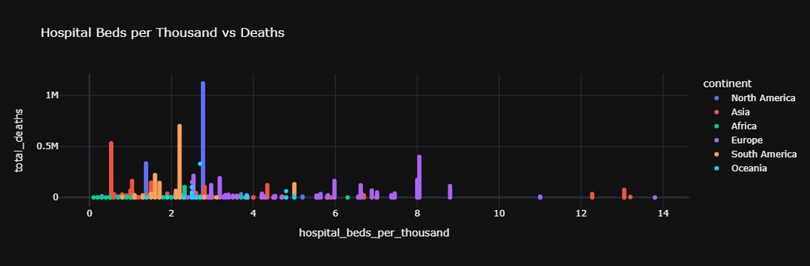

```python
def plot_hospital_beds_vs_deaths(df):
    fig = px.scatter(df, x='hospital_beds_per_thousand', y='total_deaths',
                     color='continent', title="Hospital Beds per Thousand vs Deaths",
                     hover_name='location', template="plotly_dark")
    fig.show()

plot_hospital_beds_vs_deaths(combined1)
```